# TSRethinking1 Change points and structural breaks

Wayne Zhang

10/9/2021

```r
knitr::opts_chunk$set(fig.width = 8, fig.height = 4)
rm(list=ls())  # remove variables
library(changepoint) # changing point
library(strucchange) # structural change
library(tidyverse)
library(lubridate)
library(FinCal)
```

Time series object:

- `base`: `ts` object
- `xts` or `zoo`, based on respected packages;
- `tidyverse` object.

## 1 Introduction

Problem: Time series variables may be influenced by events that arise at various points in time that alter the underlying data generating process, which influence the results of many linear time series models.

### 1.1 Change point detection

: For TS $y_t = \{y_i\}_1^T$ there is a CP, a time, if $\exists \tau\in 1:(T - 1)$ s.t. $\{y_i\}_1^\tau, \{y_i\}_{\tau + 1}^T$ have different properties.

#### Step 1 identify CP

Hypothesis:

$$\begin{aligned} H_0:& \text{ there are no CP}\\ H_1:& \exists \text{ a CP} \end{aligned}$$

method: MLE, likelihood ratio test

#### Step 2 detect the position of CPs

detect multiple CPs: thought minimizing cost function + penalty function ($f(m)$ is a penalty function could take different information criteria, like AIC, BIC, etc.)

$$\sum^{m+1}_{i=1} \left[ \mathcal{C} \left( y_{(\tau_{i-1}+1):\tau_{1}} \right) \right] + \beta f (m)$$

- Binary segmentation (critique): apply single CP method to all data and the if there is a CP using the CP seperate futher subsample applying single CP test again.
- Segment neighborhood: dynamic programming technique to get the optimal segmentation.
- The pruned exact linear time (PELT) algorithm also provides an exact solution, but is more computationally efficient

##### Change point in mean

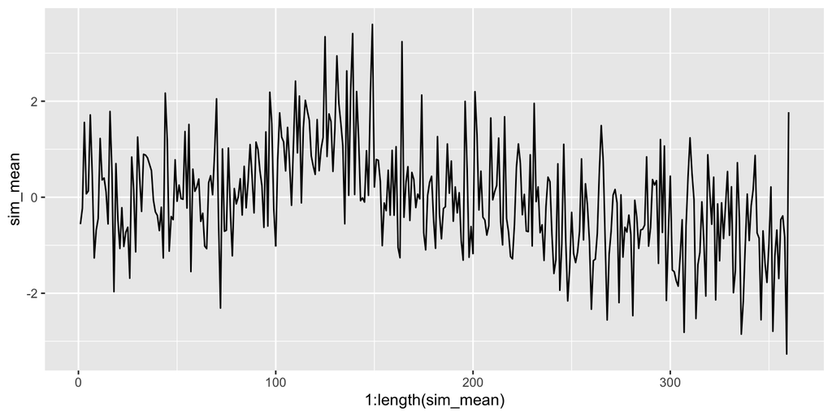

```r
set.seed(123)
sim_mean <- c(rnorm(100, 0, 1),
              rnorm(50, 1.5, 1),
              rnorm(90, 0, 1),
              rnorm(120, -0.8, 1))
qplot(1:length(sim_mean), sim_mean, geom = "path")
```

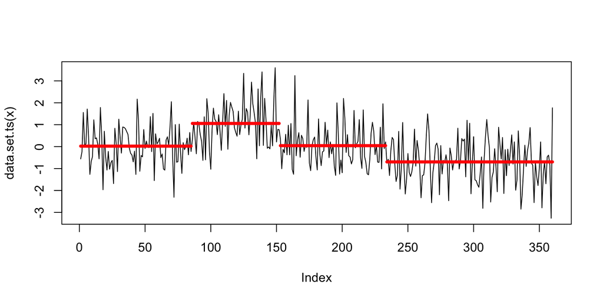

```r
# using changepoint package to identify the CP

##1.  based on mean to detect changepoint
###  binary segmentation method using BIC information criteria maximum of five breaks.
m_binseg <- cpt.mean(sim_mean, penalty = "BIC", method = "BinSeg", Q = 5)
plot(m_binseg, type = "l", xlab = "Index", cpt.width = 4)
```

```r
cpts(m_binseg) # the CP
```

```
## [1]  85 152 233
```

```r
## segment neightborhood method using BIC
m_segneigh <- cpt.mean(sim_mean, penalty = "BIC", method = "SegNeigh", Q = 5)
```

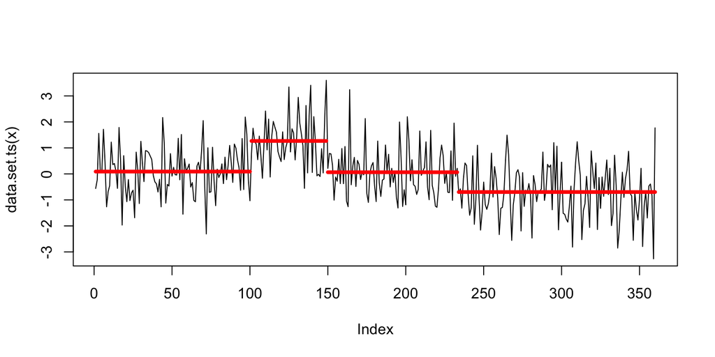

```r
plot(m_segneigh, type = "l", xlab = "Index", cpt.width = 4)
```

```r
cpts(m_segneigh) # the CP
```

```
## [1] 100 149 233
```

```r
## PELT
m_pelt <- cpt.mean(sim_mean, penalty = "BIC", method = "PELT")
plot(m_pelt, type = "l", xlab = "Index", cpt.width = 4)
cpts(m_pelt) # the CP
```

[output not shown]

```
## [1] 100 149 233
```

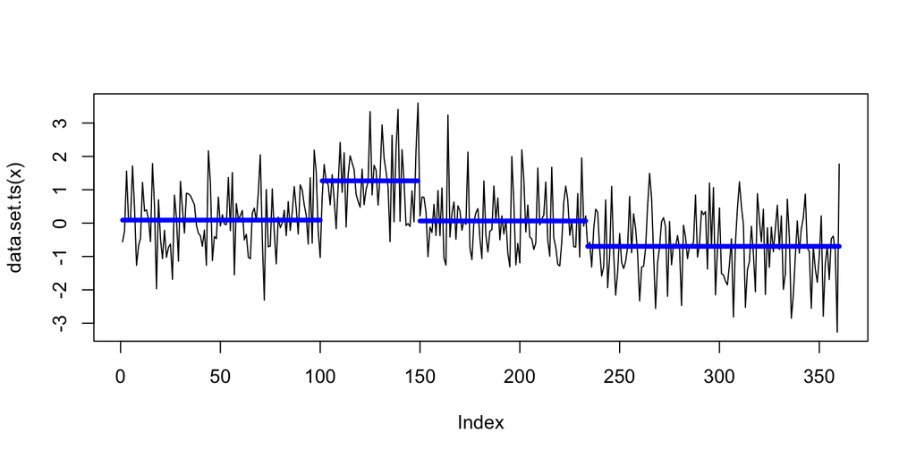

```r
# *And should we wish, we can also impose a manual penalty with the aid of the following commands:
m_pm <- cpt.mean(sim_mean, penalty = "Manual", pen.value = "1.5 * log(n)", # provide our own penalty function
                      method = "PELT")
plot(m_pm, type = "l", cpt.col = "blue", xlab = "Index", cpt.width = 4)
```

```r
cpts(m_pm)
```

```
## [1] 100 149 233
```

```r
# emperical data
rgdp <- fred("GDPC1", "1947-01-01", "2021-04-01")[, -1] %>%
    mutate(growth = 100*(price/lag(price) - 1)) %>%
    drop_na()
```

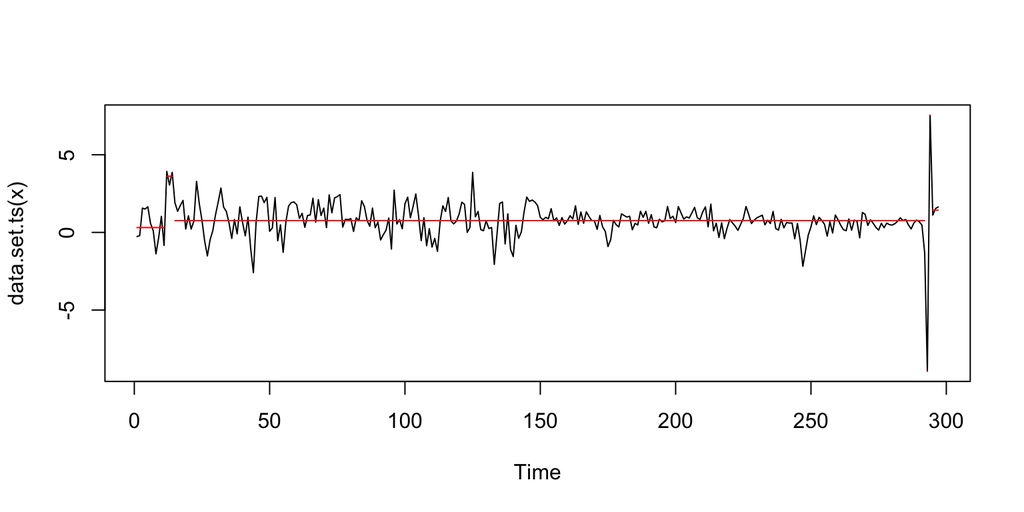

```r
m_gdp <- rgdp  %>%
    pull(growth) %>%
    cpt.mean(., penalty = "SIC", method = "PELT")
plot(m_gdp)
```

```r
cpts(m_gdp) # use this method directly we do not know the exact date of previous time
```

```
## [1]  11  14 292 293 294
```

```r
cpt <- rgdp %>%
    slice(cpts(m_gdp))
cpt
```

```
## # A tibble: 5 × 3
##   date        price growth
##   <date>      <dbl>  <dbl>
## 1 1949-10-01  2104. -0.839
## 2 1950-07-01  2340.  3.86
## 3 2020-01-01 18952. -1.30
## 4 2020-04-01 17258. -8.94
## 5 2020-07-01 18561.  7.55
```

##### Change point in variance

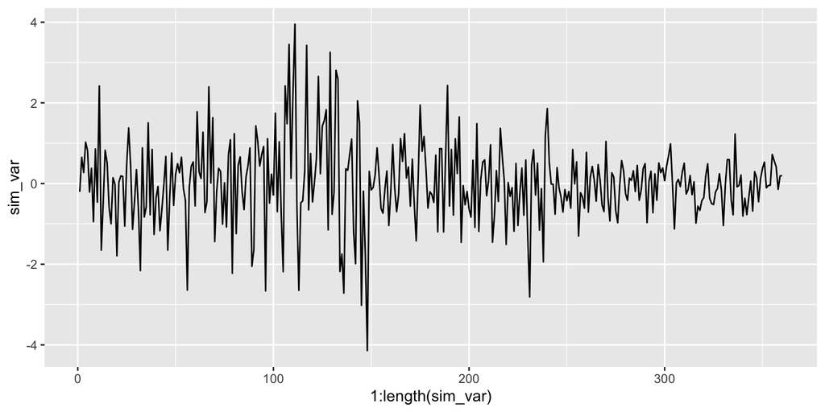

```r
sim_var <- c(rnorm(100, 0, 1),
              rnorm(50, 0, 2),
              rnorm(90, 0, 1),
              rnorm(120, 0, 0.5))
qplot(1:length(sim_var), sim_var, geom = "path")
```

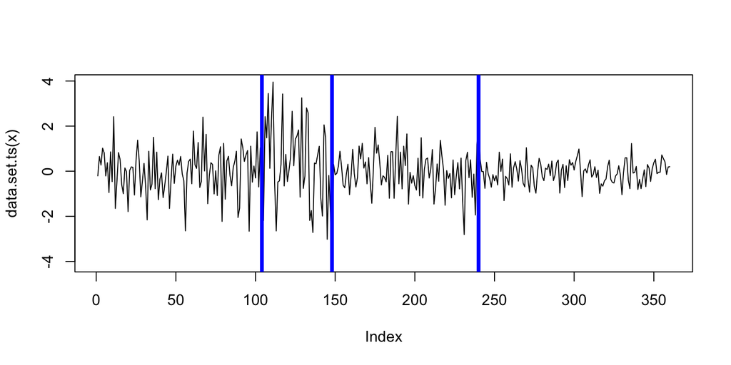

```r
##2. based on variance to to detect change point
v_pelt <- cpt.var(sim_var, method = "PELT")
plot(v_pelt, type = "l", cpt.col = "blue", xlab = "Index", cpt.width = 4)
```

```r
cpts(v_pelt)
```

```
## [1] 104 148 240
```

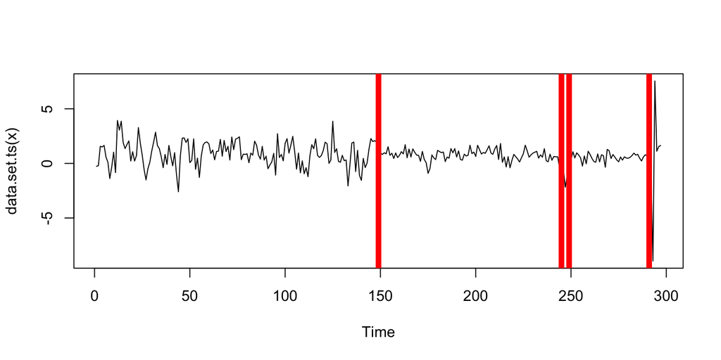

```r
# using gdp growth rate
v_gdp <- rgdp %>%
    pull(growth) %>%
    cpt.var(., method = "PELT")
plot(v_gdp, type = "l", cpt.col = "red", cpt.width = 6)
```

```r
rgdp %>%
    slice(cpts(v_gdp))
```

```
## # A tibble: 4 × 3
##   date        price growth
##   <date>      <dbl>  <dbl>
## 1 1984-04-01  7618.  1.73
## 2 2008-04-01 15793.  0.572
## 3 2009-04-01 15162. -0.169
## 4 2019-10-01 19202.  0.469
```

##### Change points in the mean and variance

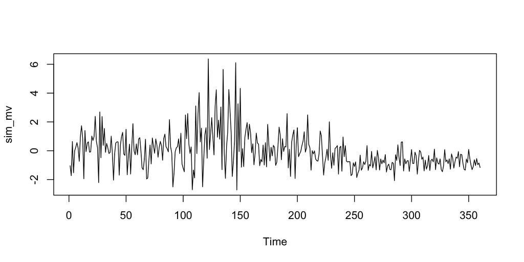

```r
sim_mv <- c(rnorm(100, 0, 1),
             rnorm(50, 1, 2),
             rnorm(90, 0, 1),
             rnorm(120, -0.8, 0.5))

plot.ts(sim_mv)
```

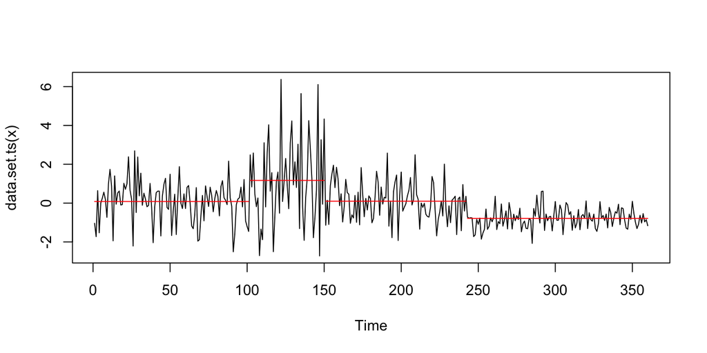

```r
mv_pelt <- cpt.meanvar(sim_mv, method = "PELT")
plot(mv_pelt)
```

```r
cpts(mv_pelt)
```

```
## [1] 101 150 242
```

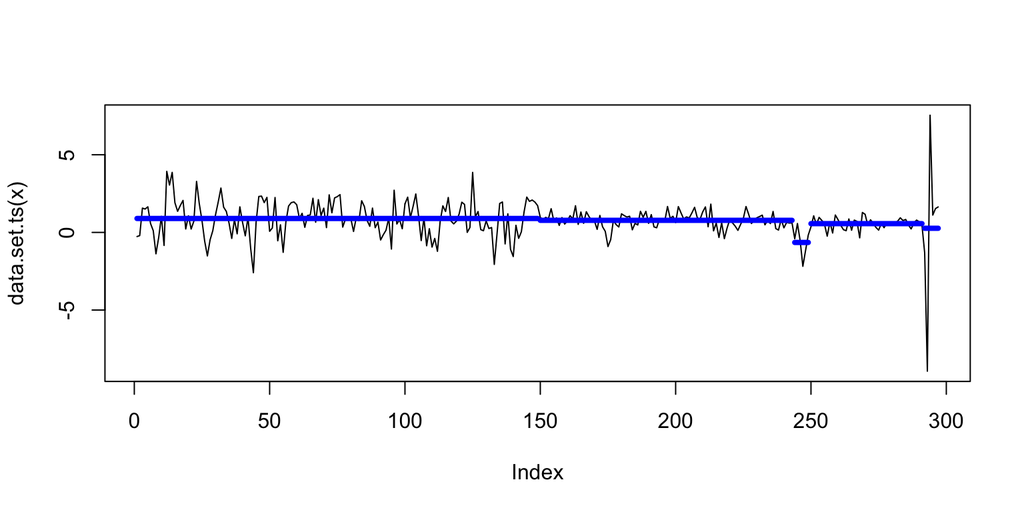

```r
mv_gdp <- rgdp %>%
    pull(growth) %>%
    cpt.meanvar(., method = "PELT")
plot(mv_gdp, type = "l", cpt.col = "blue", xlab = "Index", cpt.width = 4)
```

```r
rgdp %>%
    slice(cpts(mv_gdp))
```

```
## # A tibble: 4 × 3
##   date        price growth
##   <date>      <dbl>  <dbl>
## 1 1984-04-01  7618.  1.73
## 2 2007-10-01 15767.  0.610
## 3 2009-04-01 15162. -0.169
## 4 2019-10-01 19202.  0.469
```

### 1.2 Structural break tests

Problem: Term structural break is synonymous with change point, but would usually refer to cases where there is a change in the regression coefficients

e.g.

$$y_t = x_t^{\top} \beta_j + \varepsilon_t \;\;\; j = \{ 1, \ldots, m+1 \}$$
The hypothesis that the regression coefficients are constant may be constructed as:

$$\begin{aligned}
H_0 \; : \; \beta_j = \beta_0\\
H_1 \; : \; \beta_j \neq \beta_0
\end{aligned}$$

This test is based on the residual, $\varepsilon_t$, constructing F-statistics:

$$F_i = \frac{\hat{u}^\top\hat{u} - \hat{u}(\tau)^\top \hat{u}(\tau)}{\hat{u}(\tau)^\top \hat{u}(\tau) / \left(T-2k \right)}$$

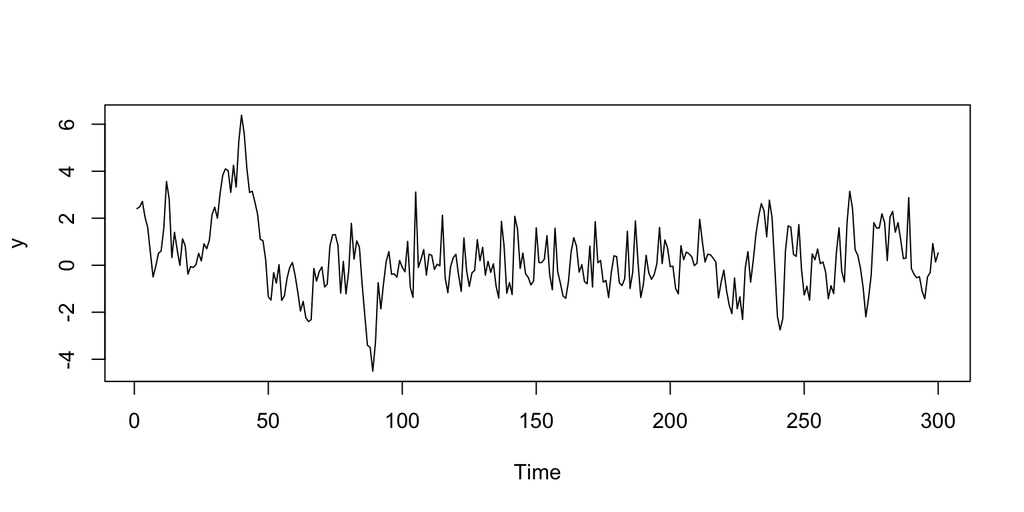

```r
rm(list = ls())
set.seed(123)

x1 <- arima.sim(model = list(ar = 0.9), n = 100)
x2 <- arima.sim(model = list(ma = 0.1), n = 100)
x3 <- arima.sim(model = list(ar = 0.5, ma = 0.3), n = 100)

y <- c((1 + x1),
       x2,
       (0.5 - x3))
plot.ts(y)
```

```r
## strucchange to test structural change

### Quandt likelihood ratio test

dat <- tibble(ylag0 = y,
              ylag1 = lag(y)
              ) %>%
  drop_na() # because we want to test AR(1) model so only need to generate one lag
qlr <- Fstats(ylag0 ~ ylag1, data = dat) # generate the Quandt Likelihood Ratio (QLR) statistic
breakpoints(qlr)
```

```
##
##   Optimal 2-segment partition:
##
## Call:
## breakpoints.Fstats(obj = qlr)
##
## Breakpoints at observation number:
## 89
##
## Corresponding to breakdates:
## 0.2943144
```

```r
sctest(qlr, type = "supF") # the significance values for structural break at this point is
```

```
##
##  supF test
##
## data:  qlr
## sup.F = 38.556, p-value = 1.57e-07
```

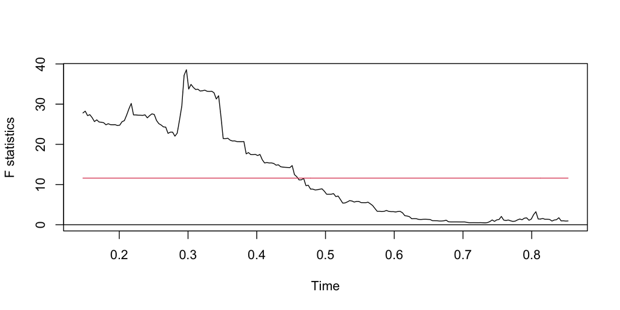

```r
plot(qlr)
```

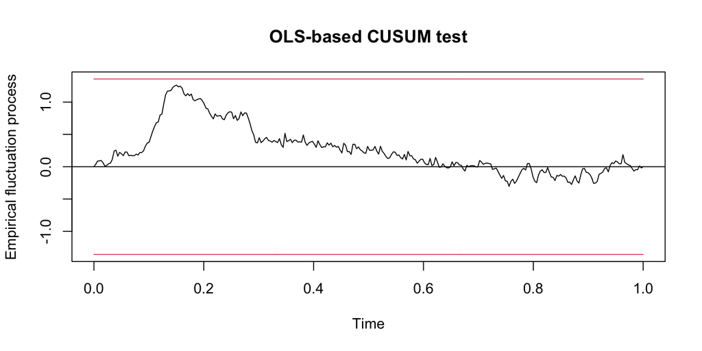

```r
### CUSUM test

cusum <- efp(ylag0 ~ ylag1, type = "OLS-CUSUM", data = dat)
plot(cusum) # this plot means the data does not contain a structural break.
```

```r
# this result is incorrect, as we did not define properly about structural break
```

```r
rgdp_dat <- fred("GDPC1", "1947-01-01", "2021-04-01")[, -1] %>%
    mutate(growth = 100*(price/lag(price) - 1),
           growth_lag = lag(growth)) %>%
    drop_na()
sa_qlr <- Fstats(growth ~ growth_lag, data = rgdp_dat)
breakpoints(sa_qlr)
```

```
##
##   Optimal 2-segment partition:
##
## Call:
## breakpoints.Fstats(obj = sa_qlr)
##
## Breakpoints at observation number:
## 250
##
## Corresponding to breakdates:
## 0.8412162
```

```r
sctest(sa_qlr, type = "supF")
```

```
##
##  supF test
##
## data:  sa_qlr
## sup.F = 35.962, p-value = 5.539e-07
```

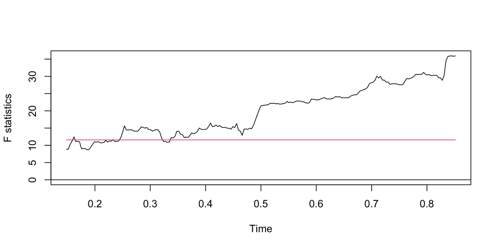

```r
plot(sa_qlr)
```

```r
rgdp_dat %>%
    slice(sa_qlr$breakpoint)
```

```
## # A tibble: 1 × 4
##   date        price growth growth_lag
##   <date>      <dbl>  <dbl>      <dbl>
## 1 2009-10-01 15379.   1.07      0.362
```

Similarly, we can perform the Bai and Perron (2003) test for multiple structural breaks with the aid of the following commands:

```r
sa_bp <- breakpoints(growth ~ growth_lag, data = rgdp_dat, breaks = 5)
summary(sa_bp)  # where the breakpoints are
```

```
##
##   Optimal (m+1)-segment partition:
##
## Call:
## breakpoints.formula(formula = growth ~ growth_lag, breaks = 5,
##     data = rgdp_dat)
##
## Breakpoints at observation number:
##
## m = 1                 250
## m = 2      75         252
## m = 3      75 138     249
## m = 4   44 88 138     249
## m = 5   44 88 138 206 250
##
## Corresponding to breakdates:
##
## m = 1
## m = 2                     0.253378378378378
## m = 3                     0.253378378378378 0.466216216216216
## m = 4   0.148648648648649 0.297297297297297 0.466216216216216
## m = 5   0.148648648648649 0.297297297297297 0.466216216216216 0.695945945945946
##
## m = 1   0.844594594594595
## m = 2   0.851351351351351
## m = 3   0.841216216216216
## m = 4   0.841216216216216
## m = 5   0.844594594594595
##
## Fit:
##
## m   0     1     2     3     4     5
## RSS 392.3 349.3 346.0 341.2 339.1 338.0
## BIC 940.5 923.1 937.5 950.3 965.6 981.8
```

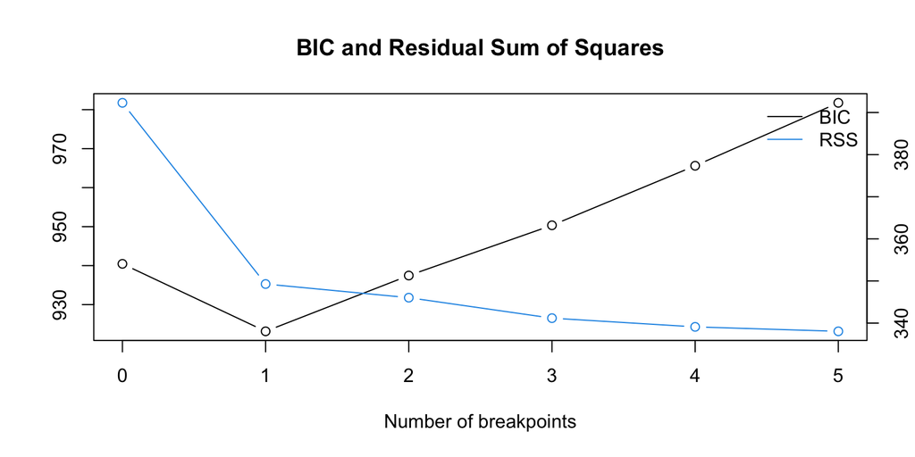

```r
plot(sa_bp, breaks = 5)
```

```r
rgdp_dat %>% slice(sa_bp$breakpoints)
```

```
## # A tibble: 1 × 4
##   date        price growth growth_lag
##   <date>      <dbl>  <dbl>      <dbl>
## 1 2009-10-01 15379.   1.07      0.362
```

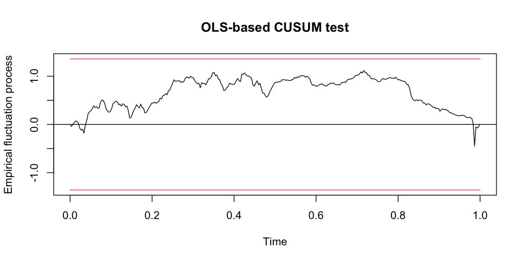

```r
sa_cusum <- efp(growth ~ growth_lag, data = rgdp_dat, type = "OLS-CUSUM")
plot(sa_cusum)
```